# Question

Al momento de realizar un viaje por carretera, un mensajero registró cuidadosamente los siguientes parámetros durante su recorrido:

| Tiempo (horas) | Costo del viaje (miles de pesos) | Combustible disponible (litros) | Distancia recorrida (kilómetros) |
| --- | --- | --- | --- |
| 0 | 0 | 64 | 0 |
| 2 | 14 | 50 | 21 |
| 4 | 34 | 44 | 40 |
| 6 | 49 | 26 | 51 |
| 8 | 67 | 16 | 70 |

Después de analizar los datos del viaje, se generaron diversas interpretaciones gráficas. ¿Cuál de las siguientes gráficas representa CORRECTAMENTE la relación entre la distancia recorrida y el combustible disponible en función del tiempo, considerando las características físicas del desplazamiento y el consumo esperado del vehículo?

## Answerlist

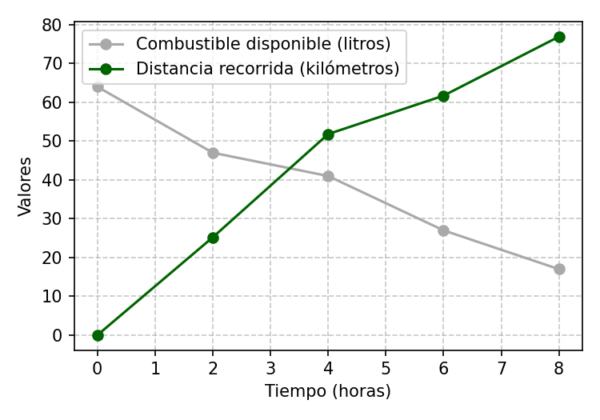

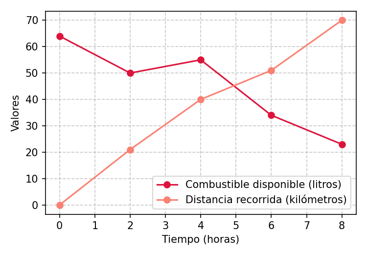

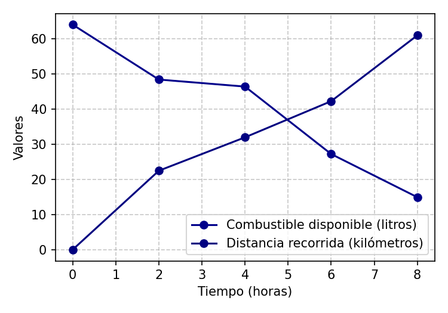

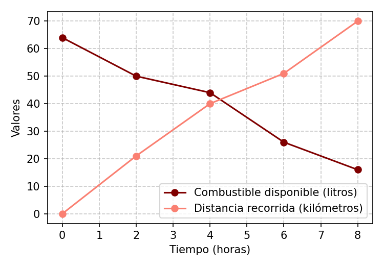

# Solution

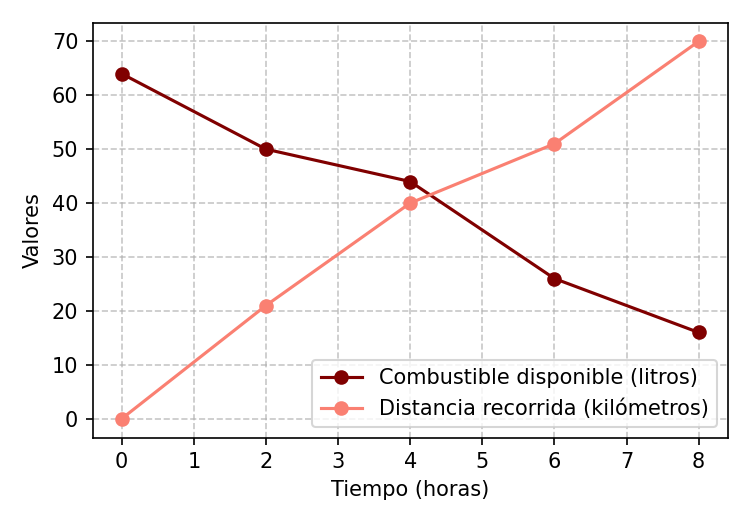

Para determinar la gráfica correcta, es necesario analizar las relaciones físicas y matemáticas que gobiernan el movimiento del vehículo y su consumo de combustible:

1. **Comportamiento del combustible**: Al examinar los datos, se observa una disminución progresiva desde 64 litros al inicio hasta 16 litros al final. Esta reducción es consistente con el consumo esperado de un vehículo en movimiento continuo, donde el combustible se consume a una tasa aproximadamente proporcional al tiempo y distancia recorrida.
2. **Comportamiento de la distancia**: Los datos muestran un incremento sistemático desde 0 km hasta 70 km. Este incremento sigue un patrón aproximadamente lineal, lo que sugiere una velocidad media relativamente constante durante el viaje.
3. **Relación entre variables**: La relación inversamente proporcional entre combustible disponible (decreciente) y distancia recorrida (creciente) representa el fenómeno físico de conversión de energía química del combustible en energía cinética y trabajo mecánico.

## Answerlist

- Falso
- Falso
- Falso
- Verdadero

# Meta-information

exname: Interpretación avanzada de gráficas de viaje extype: schoice exsolution: 0001 exshuffle: TRUE exsection: Interpretación de gráficas